# Lab 7: The Human Freedom Index

The Human Freedom Index is a comprehensive freedom index that attempts to summarize the idea of “freedom” through a bunch of different variables for many countries around the globe. It is created from numerous distinct indicators of personal (`pf`) and economic freedom (`ef`), each of which range on a scale of 0 to 10, where “10” represents more freedom.

In this lab, we will be analyzing data from Human Freedom Index reports from 2016. Our aim will be to summarize a few of the relationships within the data both graphically and numerically in order to find which variables can help tell a story about freedom. **You will be submitting the Rmd and html files as usual. Be sure to `echo=FALSE` and `eval=FALSE` for any non-exercise code chunks you create.**

**Resources** Please consult the slidedeck **Linear Regression with Single Predictor** from Week 4 on the [Class Schedule](https://canvas.uw.edu/courses/1721011/pages/class-schedule) for help with the various functions on this lab. I am also assuming that you are familiar with the lessons contained in the interactive tutorial `stat311tutorials::paris_paintings` that was assigned as an in-class activity on April 19.

**Learning Objectives**

- Fit a line using `lm`.
- Interpret the coefficients in context.
- Learn how to use a fitted model to make predictions.

## Getting Started

Launch the RStudio image on JupyterHub by clicking [here](https://jupyter.rttl.uw.edu/2024-spring-stat-311-a/user-redirect/rstudio). Create a new lab report template to save your answers to the exercises. Be sure to personalize the header with the title of the lab and also add your name. You can also change the output type to `html_document` like you did on Lab 5 and customize the theme of your report to your liking.

### Load packages

In this lab, you will explore and visualize the data using the **tidyverse** suite of packages. The data can be found in the companion package for OpenIntro resources, **openintro**. As always, we must load these packages. In addition, we will be using the **statsr** package to interactively draw a line and the **tidymodels** package to tidy regression output.

```r
library(tidyverse)
library(openintro)
library(tidymodels)   #tidy regression output
library(statsr)  #perform interactive line fitting
```

### The data

The data we’re working with is in the **openintro** package and it’s called `hfi`, short for Human Freedom Index. Load the data in your Environment

```r
data(hfi)
```

and also check out the description of the variables by typing `?hfi` in the Console. The data consists of scores on personal freedom (`pf`), economic freedom (`ef`) and human freedom (`hf`) for different countries. Due to the large number of columns, you will need to click on the arrow button on the top of the spreadsheet viewer to see all the variables.

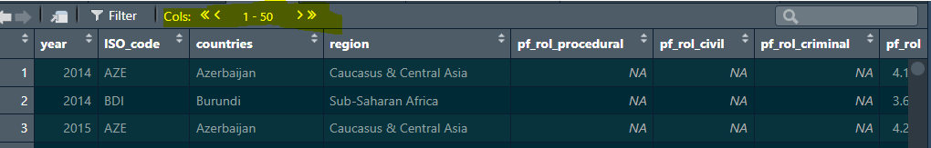

A detailed description of the project, methods and analysis can be found in the report produced by the Cato Institute [here](https://www.cato.org/sites/cato.org/files/human-freedom-index-files/human-freedom-index-2016.pdf)

## Warm up

1. The dataset spans a lot of years, but we are only interested in data from year 2016. Filter the data `hfi` data frame for year 2016 and assign the result to a data frame named `hfi_2016`. Be sure to show your code. (There will be no output)
2. How many distinct countries are in the `hfi_2016`? Show your code and output and then answer in a complete sentence.
3. Print a frequency table of the column `region` in `hfi_2016`. Which region occurs most often in this data? Least often? Be sure to show your code and the output (without messages or warnings).
4. Using `hfi_2016`, write code to make side-by-side boxplots to visualize the human freedom score `hf_score` by region. Your plot must look like this. Be sure to show your code and the output (without messages or warnings).

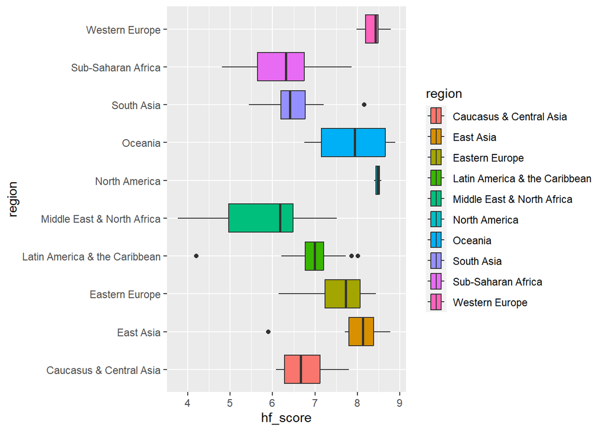

5. Write code to identify the South Asian country in your plot from Exercise 4 which has a unusually high `hf_score`. Be sure that your code only shows the name of the country. Show your code and output.

In the remainder of this lab, we will be examining how the personal freedom (`pf_score`) in a country is related to its economic freedoms (`ef_score`).

## Scatterplot smoothing

6. Using `hfi_2016`, make a properly labeled scatterplot to visualize the relationship between the personal freedom score, `pf_score` on the $x$ axis and the economic freedom score `ef_score` on the $y$ axis? Be sure to smooth the scatterplot with a line using a `geom_smooth` layer<sup>1</sup>. Just for fun, **set** the color of the points to “purple” and the color of the line to “gold”.

   Don’t forget to show your code, output (without messages or warnings) and also write one sentence to describe what you learn about the form, direction and strength of the relatonship between these variables.

If the relationship looks linear, we can quantify the strength of the relationship with the correlation coefficient $R$. This is a one number summary of the linear relationship between the two numericl variables. It is a pure number (has no units) and takes a value between -1 and +1:

- values near $\pm$ 1 indicate a strong positive or negative linear relationship,
- values near $\pm$ 0.5 indicate a moderate linear relationship
- values near 0 indicate random scatter (or possibly a non linear relationship)

The code below shows how to calculate the correlation between `pf_score` and `pf_expression_control`:

```r
#just read this
hfi_2016 %>%
  summarise(R = cor(pf_expression_control, pf_score))
```

```
## # A tibble: 1 × 1
##       R
##   <dbl>
## 1 0.845
```

*Note to student* The `cor` function has an argument `use` which controls how missing values (if any) are treated.

7. Calculate the correlation coefficient for the variables from Exercise 6. Then write a sentence summarising the strength of the linear relationship. Be sure to show code and output.

## Fitting a Line

In this section, you will use an interactive function to fit a line. You will need to run this function in your Console, so type the code shown below in a non-exercise code chunk or in your Console directly. Running the function also requires that the `hfi` and `hfi_2016` datasets are loaded in your environment.

Type the following line of code to interactively select a line that you think does the best job of going through the cloud of points. **Don’t worry if the function has trouble locating your the x and y coordinates of the points you choose.. There appears to be some issue with the functionality of the locator. Just play around with it.** 😄

```r
plot_ss(x = pf_score, y = ef_score, data = hfi_2016 )   #run in Console
```

After running this command, you’ll be prompted to click two points on the plot to define a line. Once you’ve done that, the line you specified will be shown in black and the residual - or prediction error - will be shown in blue. Note that there are many prediction errors, one for each of the observations. Recall that a residual is the difference between the actual observed values $y$ and the values $\hat{y}$ predicted by the line:

$$e = y - \hat{y}$$

The most common way to fit a line is to select the line that minimizes the sum of squares of the prediction errors:
$$e^2_1 + e^2_2 + \dots + e^2_n.$$

To visualize this quantity, you can rerun the plot command and add the argument `showSquares = TRUE`.

```r
plot_ss(x = pf_score, y = ef_score,
        showSquares=TRUE, data = hfi_2016)  #run in Console only
```

Note that the output from the `plot_ss` function provides you with the slope and intercept of your line as well as the sum of the squared residuals.

Using `plot_ss`, choose a line that you guess will do a good job of minimizing the sum of squared prediction errors. Do this five different times, hopefully improving on your ability to visually assess a line through the scatter plot. Keep track of the smallest sum of squares.

### Creating the line of best fit using lm

It is rather cumbersome to try to get the correct least squares line, i.e. the line that minimizes the sum of squared residuals, through trial and error. Instead, you can use the `lm` function in R to fit the linear model (a.k.a. regression line).

```r
m1 <- lm(pf_score ~ pf_expression_control, data = hfi_2016)
```

The first argument in the function `lm` is a formula that takes the form `y ~ x`. Here it can be read that we want to make a linear model of `pf_score` as a function of `pf_expression_control`. The second argument specifies that R should look in the `hfi_2016` data frame to find the two variables.

### Summarizing the fitted linear model

The output of `lm` is an object that contains all of the information we need about the linear model that was just fit.

We can access this information using the `tidy` function from the **tidymodels** package.

```r
tidy(m1)
```

```
## # A tibble: 2 × 5
##   term                  estimate std.error statistic  p.value
##   <chr>                    <dbl>     <dbl>     <dbl>    <dbl>
## 1 (Intercept)              4.28     0.149       28.8 4.23e-65
## 2 pf_expression_control    0.542    0.0271      20.0 2.31e-45
```

Let’s consider this output piece by piece. The result of running `tidy` is an enhanced data frame called a `tibble`. The first column shows the variables in the model: intercept and `pf_expression_control`. The second column contains the estimates of the line. The third through the fifth column contain a measure of the uncertainty and evaluation of statistical significance. These may be ignored for now.

With this table, we can write down the equation of the **line of best fit**:

$$\widehat{pf\_score} = 4.28 + 0.542 \times pf\_expression\_control.$$

This equation tells us two things:

- **Intercept** For countries with a `pf_expression_control` of 0 (those with the largest amount of political pressure on media content), we expect their personal freedom score to be 4.28.
- **Slope** When`pf_expression_control` increases by 1, we expect a country’s mean personal freedom score to increase by 0.542.
8. Fit a new model, call it m2, that uses `pf_score` to predict `ef_score`. Using the estimates from the R output, write the equation of the regression line. Be sure to show your output and code (without messages or warnings). The equation does not have to be formatted, you can write `ef_score_hat` instance. Also interpret the coefficients of the line as above.

## Making predictions

The line of best fit can be used to predict $y$ at any value of $x$. When predictions are made for values of $x$ that are beyond the range of the observed data, it is referred to as *extrapolation* and is not usually recommended. However, predictions made within the range of the data are more reliable.

9. If someone saw the equation of the line of best fit from exercise 8, what would they predict for `ef_score` in a country with a 6.7 rating for `pf_score`? Suppose the country actually has a `ef_score` of 6.5. What is the prediction error? Use R as a calculator to do your calculation. Be sure to show your code and output.

   Hint: The prediction error or residual is the actual observed value minus the predicted value. It can be positive or negative depending on whether the prediction is smaller or larger than what we observe.

## More Practice

These questions are here for more practice. They do not need to be turned in. If you do work on them, feel free to add them as non exercise code chunks in your lab report. **We should not see any output or code related to these exercises.**

- Choose another freedom variable and a variable you think would strongly correlate with it. Produce a scatter plot of the two variables and fit a linear model. At a glance, does there seem to be a linear relationship? (Note: check out the `na.action` argument for `lm` if you choose a variable which has NAs for some values.)
- How does this relationship compare to the relationship between `pf_expression_control` and `pf_score`? Use the value of $R$ to make the comparison. Does your explanatory variable seem to predict your response better? Why or why not?
- What’s one freedom relationship you were most surprised about and why?

This work is licensed under a [Creative Commons Attribution-ShareAlike 4.0 International License](http://creativecommons.org/licenses/by-sa/4.0/).

<sup>1. The grey band around the line provides a measure of uncertainty for the line. You can turn it off by setting the argument `se = FALSE` in the `geom_smooth` layer.</sup>